# Assignment 4

Import the matplotlib and numpy packages

```python
import numpy as np
import matplotlib.pyplot as plt
```

### a) For-loops and Conditional Statements

Using the lists of movie ratings and titles below, where each rating corresponds directly to the title in the same position,  
create a new list of movies that are considered top picks (**those with ratings greater than or equal to 8**):

- Use a for loop to iterate through both lists below and store the titles and ratings of movies  
  considered top picks in two new lists:
  - `top_picks_titles`: The titles of movies considered top picks.
  - `top_picks_ratings`: The ratings of top pick movies.
- Print the results of both lists.

```python
# run this cell first
movie_ratings = [6.8, 8.3, 8.5, 5.1, 8.0, 3.5, 7.8, 8.4, 7.8, 2.8, 8.8]
movie_titles = ["Barbie", "Oppenheimer", "Spider-Man: Across the Spider-Verse",
                "Morbius", "Dune", "The Emoji Movie",
                "Everything Everywhere All at Once", "Avengers: Endgame",
                "The Batman", "Cats", "Pulp Fiction"]
```

```python
# Write your answer here
top_picks_titles = []
top_picks_ratings = []

N = len(movie_titles)
for index in range(N):
    if movie_ratings[index] >= 8.0:
        top_picks_titles.append(movie_titles[index])
        top_picks_ratings.append(movie_ratings[index])

print("The titles of the top-pick movies are", top_picks_titles)
print("The ratings of the top-pick movies are", top_picks_ratings)
```

```
The titles of the top-pick movies are ['Oppenheimer', 'Spider-Man: Across the Spider-Verse', 'Dune', 'Avengers: Endgame', 'Pulp Fiction']
The ratings of the top-pick movies are [8.3, 8.5, 8.0, 8.4, 8.8]
```

### b) Follow-up to Part (a)

Using numpy, perform the following operations on the `top_picks_ratings` list:

- Count and print the total number of movies considered top picks using `np.size()`.
- Calculate and print the average ratings of the top pick movies using `np.mean()`.
- Determine and print the highest rating from the top pick movies using `np.max()`.

**You should assign each computed value to a variable**

Hint: Most numpy operations work with lists, not just arrays

```python
# Write your answer here
top_ratings_size = np.size(top_picks_ratings)
top_ratings_mean = np.mean(top_picks_ratings)
top_ratings_max = np.max(top_picks_ratings)

print("The total number of movies considered top picks is", top_ratings_size)
print("The average ratings of the top pick movies is", top_ratings_mean)
print("The highest rating from the top pick movies is", top_ratings_max)
```

```
The total number of movies considered top picks is 5
The average ratings of the top pick movies is 8.4
The highest rating from the top pick movies is 8.8
```

### c) For-loops + Plotting

- Create an array of x-values with 100 evenly spaced points between $0$ and $2\pi$  
  using `np.linspace()`. **Hint**: type `help(np.linspace)` in a separate cell to see how it is used
- Create a vector named `vec_y1` where each element is computed from the formula  
  $ y_k = \sin(x_k)$. (Here $x_k$ is the $k$-th element of the array you created above, and $y_k$ is the $k$-th element of vec_y1)
- Create a vector `vec_y2` where each element is computed from the formula  
  $ y_k = \cos(x_k)$.
- Create a list `list_vectors` with elements `vec_y1` and `vec_y2`. (So a list with two components, both being numpy arrays)
- Create a for-loop that goes through each element of `list_vectors` and plots each  
  list of $y$ values on the vertical axis against $x$ on the horizontal axis.

Note: The final output should be a 2-dimensional plot with the values from vec_y1 and vec_y2 on the vertical axis, and the $x$ values on the horizontal axis. **Remember to label the axes and add a title to the plot**.

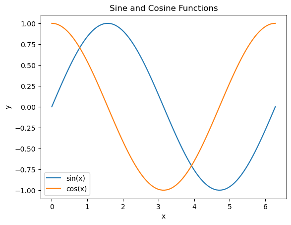

```python
# Write your answer here
x_values = np.linspace(0, 2*np.pi, num = 100)
vec_y1 = np.sin(x_values)
vec_y2 = np.cos(x_values)
list_vectors = [vec_y1, vec_y2]

plt.figure()
for vector in list_vectors:
    plt.plot(x_values, vector)

plt.xlabel('x')
plt.ylabel('y')
plt.title('Sine and Cosine Functions')
plt.legend(['sin(x)', 'cos(x)'])
plt.show()
```

### d) Learn How to Use zip()

- Below, write a chunk of code that prints out the average score for each player over the 3 rounds.  
  The names and scores are given in the lists below.
- The program should print the players's name and their average score, formatted like this:

  ```
  John's average score: ___
  Bob's average score: ___
  Jane's average score: ___
  Dave's average score: ___
  Jenny's average score: ___
  ```

- Use the `zip` function in the heading of the loop. **You should use all four lists in the heading**

Hints/Tips:

- You can learn more about zip() here: [Python zip() Function](https://www.geeksforgeeks.org/zip-in-python/)
- You can print a string followed by a float using print as follows:

```
    print(some_string, some_float)
```

- ...or you can convert the float to a string using `str`

```python
# run this cell first
player_names = ["John", "Bob", "Jane", "Dave", "Jenny"]
round1 = [120, 200, 150, 300, 180]
round2 = [100, 210, 160, 280, 190]
round3 = [130, 190, 170, 310, 175]
```

```python
# Write your answer here
average_score = []
i = 0
for player_name, r1_score, r2_score, r3_score in zip(player_names, round1, round2, round3):
    average_score.append((r1_score + r2_score + r3_score)/3)
    print(player_name + "'s average score:", average_score[i])
    i = i+1
```

```
John's average score: 116.66666666666667
Bob's average score: 200.0
Jane's average score: 160.0
Dave's average score: 296.6666666666667
Jenny's average score: 181.66666666666666
```

### e) Simulating and Visualizing

- We will generate and plot multiple histograms of sample means for the **log-normal** distribution.
- The log-normal distribution arises by raising Euler's number ($\mathrm{e}$) to the power of a number drawn from a normal distribution. This is the *underlying* normal distribution.
- If $\mu$ is the mean of the underlying normal distribution, and $\sigma$ is the standard deviation of the underlying normal distribution, then: $$ \textrm{mean of log-normal distribution } = \mathrm{e}^{\mu + \frac{\sigma^2}{2}} = \exp\left(\mu + \frac{\sigma^2}{2} \right)$$
- For this question, we will use $\mu = 1$ and $\sigma = 0.5$
- Generate and plot multiple histograms showing the frequency of sample means computed with different sample sizes:
  - Create 3 histograms: one with sample size 10, one with sample size 100, and one  
    with sample size 1000.
  - Make sure that the number of simulations is the same for all three (keep the number  
    of simulations set to 2000)
- Using your histograms from the question above, how does the sample size affect the  
  distribution of the sample means? Answer this question in a markdown cell or as a comment in a Python cell.
- **Hint**: you will want to use the function `np.random.lognormal`

### Write your answers in the cells below

```python
# Sample Size 10

np.random.seed(1234) # set the seed for reproducibility
num_simulations = 2000


# complete the code
mu = 1
sigma = 0.5

mean_sample_10 = []

for i in range(num_simulations):
    sample_10 = np.random.lognormal(mean = mu, sigma = sigma, size = 10)
    mean_sample_10.append(np.mean(sample_10))
```

```python
# Sample Size 100

np.random.seed(1234) # set the seed for reproducibility
num_simulations = 2000

# complete the code
mean_sample_100 = []

for i in range(num_simulations):
    sample_100 = np.random.lognormal(mean = mu, sigma = sigma, size = 100)
    mean_sample_100.append(np.mean(sample_100))
```

```
The true mean of log-normal distribution is 3.080216848918031
```

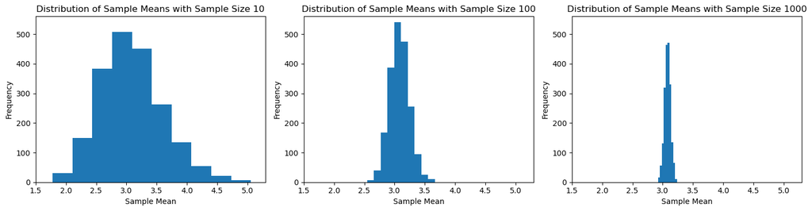

```python
# Sample Size 1000

np.random.seed(1234) # set the seed for reproducibility
num_simulations = 2000

# complete the code
mean_sample_1000 = []

for i in range(num_simulations):
    sample_1000 = np.random.lognormal(mean = mu, sigma = sigma, size = 1000)
    mean_sample_1000.append(np.mean(sample_1000))

log_mean = np.exp(mu + sigma**2 / 2)
print("The true mean of log-normal distribution is", log_mean)

fig, subfig_array = plt.subplots(nrows = 1, ncols = 3, figsize = (15, 4))

subfig_array[0].hist(x = mean_sample_10)
subfig_array[0].set_title("Distribution of Sample Means with Sample Size 10")
subfig_array[0].set_xlabel("Sample Mean")
subfig_array[0].set_ylabel("Frequency")
subfig_array[0].set_xlim(1.5, 5.3)
subfig_array[0].set_ylim(0, 560)

subfig_array[1].hist(x = mean_sample_100)
subfig_array[1].set_title("Distribution of Sample Means with Sample Size 100")
subfig_array[1].set_xlabel("Sample Mean")
subfig_array[1].set_ylabel("Frequency")
subfig_array[1].set_xlim(1.5, 5.3)
subfig_array[1].set_ylim(0, 560)

subfig_array[2].hist(x = mean_sample_1000)
subfig_array[2].set_title("Distribution of Sample Means with Sample Size 1000")
subfig_array[2].set_xlabel("Sample Mean")
subfig_array[2].set_ylabel("Frequency")
subfig_array[2].set_xlim(1.5, 5.3)
subfig_array[2].set_ylim(0, 560)

plt.tight_layout()
plt.show()
```

```python
# How does the sample size affect the distribution of the sample means?

# Write your answer as a comment below, or create a markdown cell.
```

As the sample size increases, the distribution of the sample means becomes more centered around the true mean of the log-normal distribution.